# Estudio de personas con discapacidad en el año 2012

### Variables `Género` y `Departamento` vs `Discapacidad sensorial`

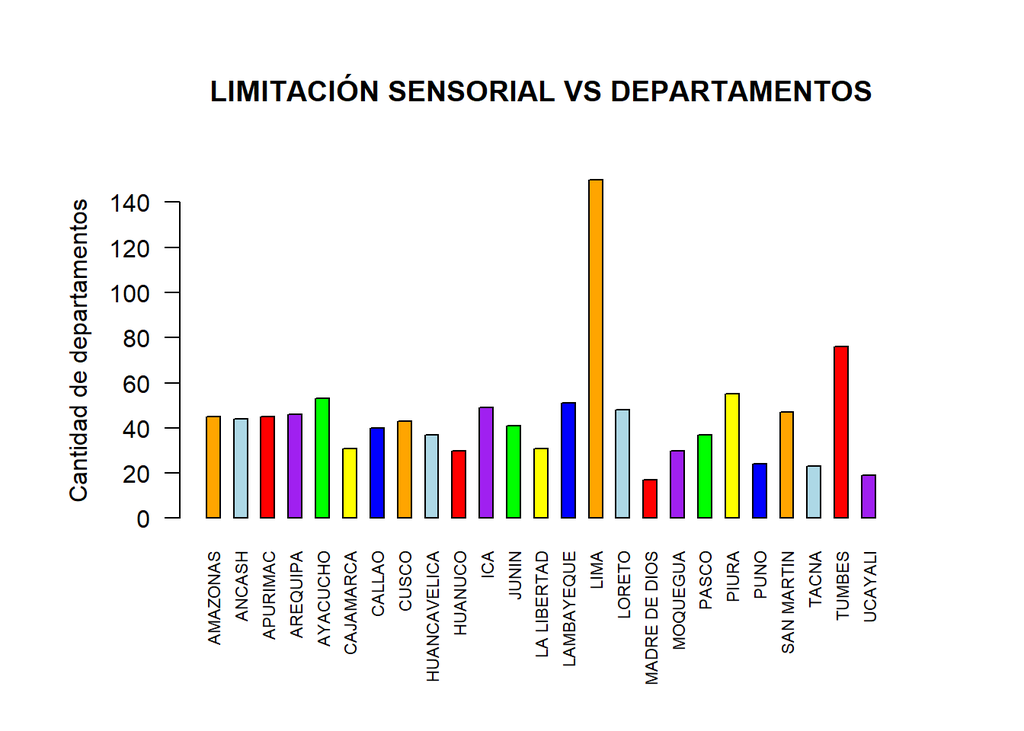

```r
disc_senso<-filter(EDP,EDP$Discapacidad_Sensorial=="Si")
color = c("orange","light blue","red","purple","green","yellow", " blue")
op<-par( mar= c(5,4,4,2)+2.15)
barplot(table(disc_senso$Departamento), ylab="Cantidad de departamentos", ,main="LIMITACIÓN SENSORIAL VS DEPARTAMENTOS", col= color, horiz=FALSE, cex.names = 0.7,las=2, space = 1)
```

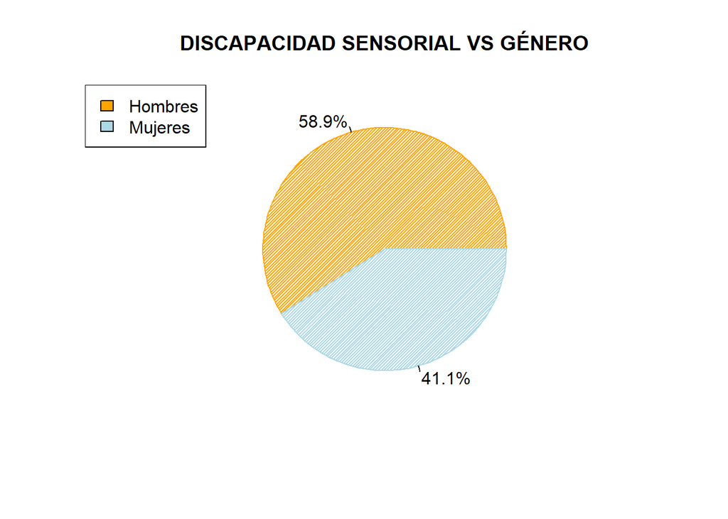

```r
par(op)
count_3 <- redondeo(c((table(disc_senso$Genero)/nrow(disc_senso))*100))
pie(count_3, labels = paste0(count_3, "%"),col=c("orange", "lightblue"), density = 50, angle = 45,main="DISCAPACIDAD SENSORIAL VS GÉNERO")

legend("topleft", legend = c("Hombres", "Mujeres"),
       fill =  c("orange", "lightblue"))
```

En las gráfica de discapacidad sensorial por departamento podemos observar que la mayor cantidad de estas personas en la muestra se encuentran en el departamento de Lima y la menor cantidad se encuentra en Madre de Dios. En la gráfica de discapacidad sensorial por género podemos observar que en la muestra el hombre sufre más de esta discapacidad.

### Variables `Departamento` vs `Colegio con infraestrctura especializada`

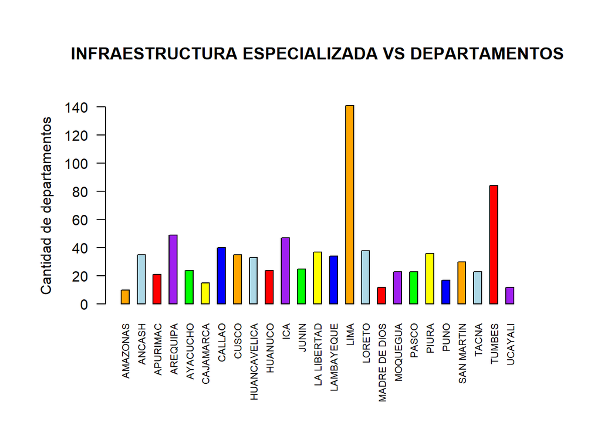

```r
colegio_infraestructura<-filter(EDP,EDP$Infraestructura=="Si")
maxC<-max(table(colegio_infraestructura$Departamento))
minC<-min(table(colegio_infraestructura$Departamento))
color = c("orange","light blue","red","purple","green","yellow", " blue")
op<-par( mar= c(5,4,4,2)+2.15)
barplot(table(colegio_infraestructura$Departamento), ylab="Cantidad de departamentos", ,main="INFRAESTRUCTURA ESPECIALIZADA VS DEPARTAMENTOS", col= color, horiz=FALSE, cex.names = 0.7,las=2, space = 1)
```

```r
par(op)
```

Lo que podemos observar de esta gráfica es que la mayor cantidad de colegios con infraestructura especializada se encuentran en el departamento de Lima y son 141. Por el contrario la menor cantidad de estos colegios se encuentran en el departamento de Amazonas con 10.

### Variables `Departamento` vs `Colegio con profesores especializados`

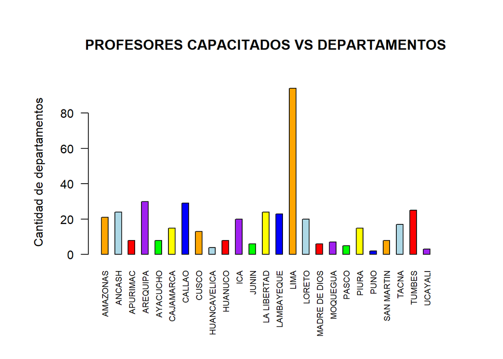

```r
colegio_capacitado<-filter(EDP,EDP$Colegio_con_profesores_especializados=="Si")
maxC<-max(table(colegio_capacitado$Departamento))
minC<-min(table(colegio_capacitado$Departamento))
color = c("orange","light blue","red","purple","green","yellow", " blue")
op<-par( mar= c(5,4,4,2)+2.15)
barplot(table(colegio_capacitado$Departamento), ylab="Cantidad de departamentos", ,main="PROFESORES CAPACITADOS VS DEPARTAMENTOS", col= color, horiz=FALSE, cex.names = 0.7,las=2, space = 1)
```

```r
par(op)
```

Lo que podemos observar de esta gráfica es que la mayor cantidad de colegios con profesores capacitados se encuentran en el departamento de Lima y son 94. Por el contrario la menor cantidad de estos colegios se encuentran en el departamento de Puno con 2.

### Variables `Departamento` vs `Colegio con tecnologías especializada`

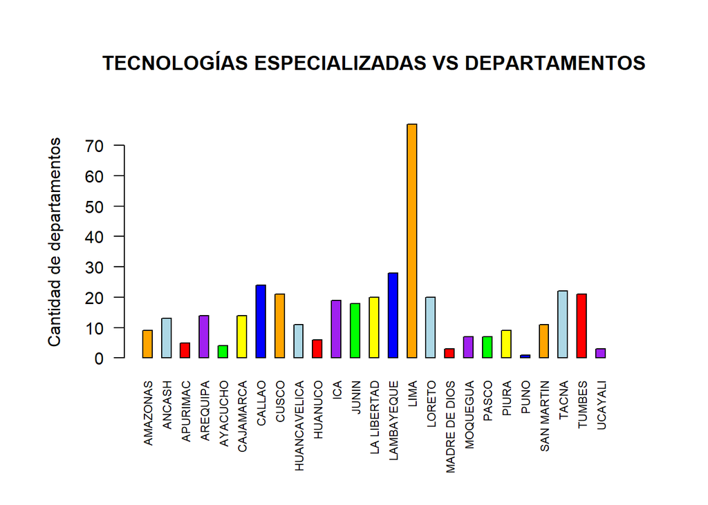

```r
colegio_tecbnologia<-filter(EDP,EDP$Tecnologias_especializadas=="Si")
maxC<-max(table(colegio_tecbnologia$Departamento))
minC<-min(table(colegio_tecbnologia$Departamento))
color = c("orange","light blue","red","purple","green","yellow", " blue")
op<-par( mar= c(5,4,4,2)+2.15)
barplot(table(colegio_tecbnologia$Departamento), ylab="Cantidad de departamentos", ,main="TECNOLOGÍAS ESPECIALIZADAS VS DEPARTAMENTOS", col= color, horiz=FALSE, cex.names = 0.7,las=2, space = 1)
```

```r
par(op)
```

Lo que podemos observar de esta gráfica es que la mayor cantidad de colegios con tecnologías especializadas se encuentran en el departamento de Lima y son 77. Por el contrario la menor cantidad de estos colegios se encuentran en el departamento de Puno con 1.

### Variables `Departamento` vs `Colegio con materiales necesarios`

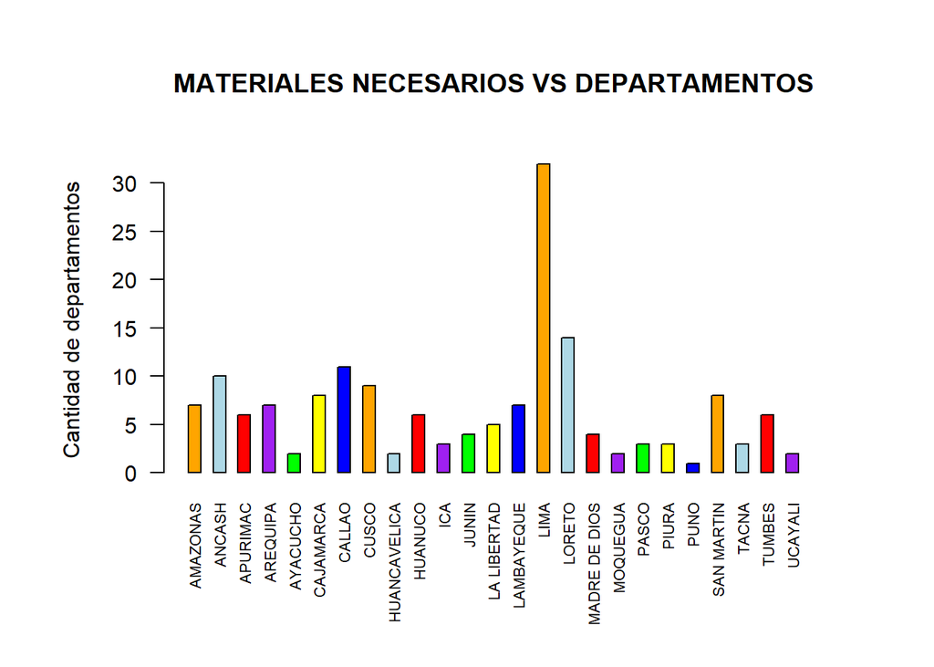

```r
colegio_materiales<-filter(EDP,EDP$Materiales_necesarios_para_enseñar=="Si")
maxC<-max(table(colegio_materiales$Departamento))
minC<-min(table(colegio_materiales$Departamento))
color = c("orange","light blue","red","purple","green","yellow", " blue")
op<-par( mar= c(5,4,4,2)+2.15)
barplot(table(colegio_materiales$Departamento), ylab="Cantidad de departamentos", ,main="MATERIALES NECESARIOS VS DEPARTAMENTOS", col= color, horiz=FALSE, cex.names = 0.7,las=2, space = 1)
```

```r
par(op)
```

Lo que podemos observar de esta gráfica es que la mayor cantidad de colegios con materiales necesarios para que el alumno pueda aprender se encuentran en el departamento de Lima y son 32. Por el contrario la menor cantidad de estos colegios se encuentran en el departamento de Puno con 1.

## **Variables aleatorias**

### **Variable** `Discapacidades`

Antes de pasar al planteamiento de los modelos de distribución de las variables de interés, tenemos que conocer a la población. Para esto utilizaremos la información sobre el total de la cantidad de personas discapacitadas en el Perú este año 2022 y la cantidad de personas discapacitadas por tipo de discapacidad. Esta información fue obtenida de la página del gobierno peruano la cual el observatorio nacional de la discapacidad, en el apartado de “estadística” en la sección de “Reportes mensuales” (https://conadisperu.gob.pe/observatorio/estadisticas/informe-estadistico-del-registro-nacional-de-la-persona-con-discapacidad-reporte-abril-2022/).

Lo que hicimos fue agrupar las diferentes discapacidades en 4 generales como se realizó previeamente para poder realizar este análisis.